# Point étape n°4

Auteur·rice

Cefil 2023

**La situation**

Vous êtes chargé d’étude à la Direction Régionale de Nouvelle-Aquitaine. On vous demande de décrire la population, l’emploi et l’accès aux équipements de différents territoires, en illustrant ces thématiques par des indicateurs, des tableaux, des graphiques et des cartes. Ces éléments seront regroupés, au final, dans des documents reproductibles, en vu de créer un atlas régional annualisé.

## 1 Travail préparatoire: vos scripts, vos données.

**À faire**

1. Lancez **RStudio**. Créez un nouveau script que vous sauvegarderez dans le sous-répertoire `Documents/Parcours R/miniprojet`. Attribuez lui le nom `Point_etape_4.R`.
2. Téléchargez le fichiers de données `PointEtape3.RData` sur la plateforme moodle et copiez les dans un sous-répertoire `donnees/miniprojet/PE4`.

**Aide**

**Séquence 1:**

*Installation de R et RStudio (par le centre logiciel et par téléchargement).*

*Configuration de RStudio, premiers scripts (création, ouverture, modification, enregistrement).*

## 2 Répertoire de travail, packages et imports de fichiers

**À faire**

1. Définissez votre répertoire de travail.
2. Charger les packages `dplyr` et `gt`(installez-les, si besoin)

**Aide**

**Séquence 5:**

*Installation de packages, utilisation. Repérer un package selon ses besoins.*

## 3 Imports des bases

**À faire**

Charger les bases en mémoire en important le fichier d’environnement `PointEtape3.RData`

**Aide**

**Séquence 5:**

*Imports et exports aux formats rds, RData, SAS, csv, xls.*

## 4 Préparation de la base pour les tableaux

**À faire**

1. À partir de l’objet `base_fusion`, créer le jeu de données `base_tableaux` qui ne conserve que les colonnes `CODGEO`, `LIBGEO`, `reg` (qui sera renommée `REG`), `DEP`, `LIBDEP`, `P13_POP`, `P19_POP`, `NAIS1319`, `DECE1319`, `evol_pop_abs`, `evol_pop_rel`, `trpop`, `P19_LOG`, `P19_RP`, `P19_CHOMEUR1564`, `P19_ACT1564`
2. Affichez la structure de la table `regions`. Quel sera le problème lorsqu’on souhaitera enrichir `base_tableaux` avec les noms des régions issus de cette table de passage (variable `LIBREG`) ?
3. Modifiez le type de la variable `REG` de `regions` en type character puis attribuez les bons codes aux régions des DOM (on pourra, par exemple, concaténer un “0” devant les codes régions à un seul chiffre).
4. Utilisez une jointure pour enrichir `base_tableaux` avec les libellés des régions.

**Aide**

**Séquence 9:**

*Sélection de colonnes avec `select()`*

**Tester les codes à un seul chiffre:**

Utilisez la fonction `nchar()` qui renvoie le nombre de caractères d’une chaîne.

**Code pour la question 3:**

```r
regions <- regions %>%
  mutate(REG = case_when(
    REG == 1 ~ "01",
    REG == 2 ~ "02",
    REG == 3 ~ "03",
    REG == 4 ~ "04",
    REG == 6 ~ "06",
    TRUE ~ as.character(REG)
  )
  )

# regions <- regions %>% # code alternatif, faisant appel à la recherche de chaines de caractères
#   mutate(REG = as.character(REG),
#          REG = if_else(nchar(REG) == 1, paste0("0", REG), REG))
regions
```

## 5 Tableau 1: préparation des données

**À faire**

L’objectif est de construire base_1 (qui sera mis en forme ensuite) prenant cette forme:

```r
> base_1
# A tibble: 15 × 5
   Territoire                     POP2013  POP2019 evol_anmoy_rel evol_anmoy_abs
   <chr>                            <dbl>    <dbl>          <dbl>          <dbl>
 1 Charente                        353065   351577      -0.000704          -248
 2 Charente-Maritime               633417   651358       0.00467           2990.
 3 Corrèze                         240781   240073      -0.000491          -118
 4 Creuse                          120872   116617      -0.00596           -709.
 5 Deux-Sèvres                     371632   374878       0.00145            541
 6 Dordogne                        416909   413223      -0.00148           -614.
 7 Gironde                        1505517  1623749       0.0127           19705.
 8 Haute-Vienne                    375856   372359      -0.00156           -583.
 9 Landes                          397226   413690       0.00679           2744
10 Lot-et-Garonne                  333180   331271      -0.000957          -318.
11 Pyrénées-Atlantiques            664057   682621       0.00461           3094
12 Vienne                          431248   438435       0.00276           1198.
13 Nouvelle-Aquitaine             5843760  6009851       0.00468          27682.
14 France métropolitaine         63692673 65091693       0.00363         233170
15 France entière (hors Mayotte) 65559564 66983328       0.00359         237294
```

1. Créer le jeu de données `base_1` à partir de `base_tableaux` en filtrant les communes de Nouvelle-Aquitaine (code région `REG == 75`), puis calculer la population de chaque département en 2013 et 2019 en les appelant `POP2013` et `POP2019`.
2. Concaténez cette table avec une table contenant les populations de la région. Pensez à créer une colonne `LIBDEP` prenant la valeur “Nouvelle-Aquitaine” pour éviter une valeur manquante après la concaténation.
3. Concaténez à nouveau avec les population `POP2013` et `POP2019` de la France métropolitaine (`REG` différent de “01”, “02”, “03”, “04” et “06”), puis concaténez à nouveau avec les populations 2013 et 2019 de la France entière (hors Mayotte).
4. Calculer les évolutions annuelles moyennes brutes et relatives (colonnes `evol_anmoy_abs` et `evol_anmoy_rel`)

**Aide**

**Séquence 15:**

*La fonction `bind_rows()` concatène deux tables possédant les mêmes colonnes.*

**Calcul des évolutions moyennes**

Pour l’évolution brute, on divisera l’écart de population par le nombre d’années séparant les deux millésime. Pour l’évolution relative moyenne, on utilisera la racine nième pour obtenir le taux moyen annuel.

## 6 Création du Tableau 1

**À faire**

Nous allons reproduire le tableau suivant:

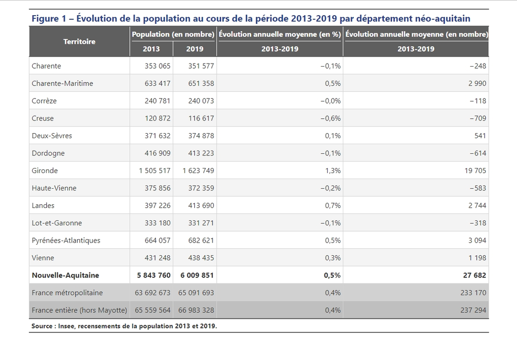

1. Appliquez la fonction `gt()` du package *gt* à `base_1`. Spécifiez le paramètre `id = "poptable"` à l’intérieur de cette fonction, qui nous servira à la fin. Affectez ce tableau à un objet nommé `tab_1`.

   *Note: Ce paramètre permet de tagger le tableau dans la sortie html, afin d’appliquer des styles CSS spéciaux.*
2. Intégrez le titre “Figure 1 – Évolution de la population au cours de la période 2013-2019 par département néo-aquitain” et la source “Source : Insee, recensements de la population 2013 et 2019.” au tableau.
3. A l’aide de la fonction `tab_spanner()`, créez les en-têtes de colonnes suivantes:
   - **“Population (en nombre)”** pour les colonnes `POP2013` et `POP2019`
   - **“Évolution annuelle moyenne (en %)”** pour la colonne `evol_anmoy_rel`
   - **“Évolution annuelle moyenne (en nombre)”** pour la colonne `evol_anmoy_abs`
4. A l’aide de la fonction `cols_label()`, renommez les colonnes:
   - `POP2013` en “2013”,
   - `POP2019` en “2019”
   - `evol_anmoy_rel` en “2013-2019”
   - `evol_anmoy_abs` en “2013-2019”

**Aide**

**Séquence 18: Produire un tableau de données**

*Fonction `gt()`*

**Séquence 19: Mettre en forme un tableau de données**

*Le titre et la source `tab_header()` et `tab_source_note()`.*

*En-têtes de colonnes `tab_spanner()`, noms de colonnes `cols_label()`*

## 7 Formats des colonnes

**À faire**

1. Appliquez la fonction `fmt_number`() pour formater les colonnes `POP2013`, `POP2019`, `evol_anmoy_abs`. Les nombres seront sans décimales et avec un espace comme séparateur de milliers.
2. Appliquez la fonction `fmt_percent`() pour formater la colonne `evol_anmoy_rel`. Les pourcentages seront affichés avec une seule décimale, un espace comme séparateur de milliers et une virgule comme séparateur décimal.

**Aide**

**Séquence 18: Produire un tableau de données**

*Fonctions de formatages `fmt_number(`) et `fmt_percent()`.*

## 8 Personnalisation du tableau

**À faire**

1. À l’aide de la fonction `opt_stylize()`, choisissez le type numéro 6, de couleur grise (`gray`) et aux lignes alternées.
2. À l’aide de la fonction `tab_style()`, modifiez:
   - le titre en gras, aligné à gauche et de couleur `royalblue4`
   - la source en gras
   - les entêtes de colonnes, `cells_column_spanners()`, prennent des bordures blanches, texte en gras (note: on peut appliquer plusieurs `style` à la même `locations` avec une `list()`.
   - les noms de colonnes, `cells_column_labels(),` auront des bordures blanches, le texte en gras, centré et aligné verticalement au milieu
   - les cellules de données `cells_body()` avec des bordures gris clair (`lightgrey`)
   - la ligne “Nouvelle-Aquitaine” en gras (`cells_body(rows = Territoire == "Nouvelle-Aquitaine")`)
   - la ligne “France métropolitaine” avec un fond de couleur `grey82`
   - la ligne “France entière (hors Mayotte)” avec un fond de couleur `grey75`
3. Rajoutez la ligne suivante pour régler le problème des bordures des en-têtes:

```r
opt_css(css = "#poptable .gt_column_spanner {border-bottom-color: white; border-bottom-width:1px}")
```

**Aide**

**Séquence 19: Mettre en forme un tableau de données**

*Fonctions d’habillages `opt_stylize()` et `tab_style()`.*

## 9 Tableau 2: Communes de plus de 50 000 habitants de Nouvell-Aquitaine

**À faire**

Nous allons reproduire le tableau suivant:

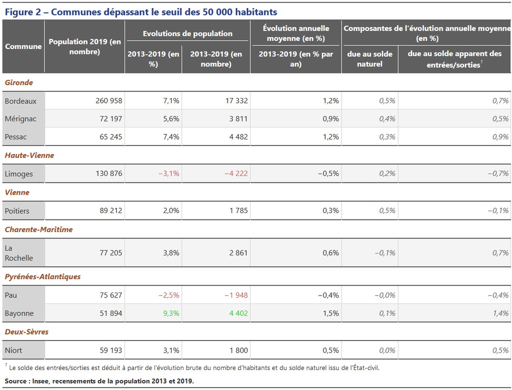

1. Préparez `base_2` à partir de `base_tableaux` en filtrant les communes de région Nouvelle-Aquitaine (code “75”) de plus de 50000 habitants en 2019. Triez par nombre décroissant d’habitants et calculez les indicateurs suivants:
   - Le solde naturel entre 2013 et 2019: `SN1319 = NAIS1319 - DECE1319`
   - Le taux moyen annuel: `evol_pop_moy = (P19_POP/P13_POP)^(1/6) - 1`
   - La contribution du solde naturel à l’évolution annuelle moyenne: `evol_pop_moy_SN = evol_pop_moy * SN1319/evol_pop_abs`
   - Idem pour le solde apparent des entrées/sorties: `evol_pop_moy_SMA = evol_pop_moy - evol_pop_moy_SN`
   - Ne conservez que les colonnes: `LIBGEO`, `LIBDEP`, `P19_POP`, `evol_pop_rel`, `evol_pop_abs`, `evol_pop_moy`, `evol_pop_moy_SN` et `evol_pop_moy_SMA`
2. Créez le tableau `tab_2` avec l’identifiant `id = "villeplus50000"`, les en-têtes de lignes LIBGEO et les groupes par département `groupname_col = "LIBDEP"`. Le titre *“Figure 2 – Communes dépassant le seuil des 50 000 habitants”*, la source *“Source : Insee, recensements de la population 2013 et 2019.”)* et une note de bas de tableaux “*Le solde des entrées/sorties est déduit à partir de l’évolution brute du nombre d’habitants et du solde naturel issu de l’État-civil.*” sur `locations = cells_column_labels(columns = evol_pop_moy_SMA)`
3. Créez les en-têtes de colonnes suivants:
   - “Evolutions de population” pour les colonnes `evol_pop_rel` et `evol_pop_abs`
   - “Évolution annuelle moyenne (en %)” pour la colonne `evol_pop_moy`
   - “Composantes de l’évolution annuelle moyenne (en %)” pour les colonnes `evol_pop_moy_SN` et `evol_pop_moy_SMA`
4. Les étiquettes de colonnes (fonction `cols_label()`) :
   - `LIBGEO` = “Commune”
   - `P19_POP` = “Population 2019 (en nombre)”
   - `evol_pop_rel` = “2013-2019 (en %)”
   - `evol_pop_abs` = “2013-2019 (en nombre)”
   - `evol_pop_moy` = “2013-2019 (en % par an)”
   - `evol_pop_moy_SN` = “due au solde naturel”
   - `evol_pop_moy_SMA` = “due au solde apparent des entrées/sorties”
5. L’étiquette des entêtes de lignes: `tab_stubhead(label = "Commune")`
6. Les colonnes `P19_POP`, `evol_pop_abs` formatées en nombre entiers et l’espace comme séparateur de milliers. Les colonnes `evol_pop_rel`, `evol_pop_moy`, `evol_pop_moy_SN` et `evol_pop_moy_SMA` comme pourcentages avec une décimale, l’espace comme séparateur de milliers et la virgule comme séparateur décimal.

**Aide**

**Séquence 18: Produire un tableau de données**

**Séquence 19: Mettre en forme un tableau de données**

## 10 Personnalisation du tableau

**À faire**

**Aide**

```r
  opt_stylize(style = 6,
              color = "gray",
              add_row_striping = TRUE) %>%
  tab_style(
    style = cell_text(color = "royalblue4", weight = "bold", align = "left"),
    locations = cells_title("title")
  ) %>%
  tab_style(
    style = cell_text(weight = "bold"),
    locations = cells_source_notes()
  ) %>%
  tab_style(
    style = list(cell_borders(sides = "all", color = "white"), cell_text(weight = "bold", align = "center", v_align = "middle")),
    locations = list(cells_column_labels(), cells_stubhead(), cells_column_spanners())
  ) %>%
  tab_style(
    style = cell_borders(sides = "all", color = "lightgrey"),
    locations = cells_body()
  ) %>%
  opt_css(css = "#villeplus50000 .gt_column_spanner {border-bottom-color: white; border-bottom-width:1px}")
```

## 11 Exports

**À faire**

1. Exportez l’environnement dans un fichier `exports/PointEtape4.RData`
2. Sauvegardez les tableaux dans des fichiers séparés *tab_1.html* et *tab_2.html*

**Aide**

**Séquence 5:**

*Imports et exports aux formats rds, RData, SAS, csv, xls*

**Séquence 19: Mettre en forme un tableau de données**

*Fonction `gtsave()`*